# 6. Dynamic Programming II

6. Dynamic Programming II

WU Xiaokun 吴晓堃

xkun.wu [at] gmail

2021/11/05

# Sequence alignment

## String similarity

**Q**. How similar are two strings?

**Ex**. ocurrance and occurrence.

| o | c | u | r | r | a | n | c | e | - |  |
| --- | --- | --- | --- | --- | --- | --- | --- | --- | --- | --- |
| o | c | c | u | r | r | e | n | c | e |  |
|  |  | * | * |  | * | * | * | * | - |  |
| o | c | - | u | r | r | a | n | c | e |  |
| o | c | c | u | r | r | e | n | c | e |  |
|  |  | - |  |  |  | * |  |  |  |  |
| o | c | - | u | r | r | - | a | n | c | e |
| o | c | c | u | r | r | e | - | n | c | e |
|  |  | - |  |  |  | - | - |  |  |  |

## Edit distance

**Edit distance**. [Levenshtein 1966, Needleman–Wunsch 1970]

- **Gap** penalty $\delta$; **mismatch** penalty $\alpha_{pq}$.
- Cost = sum of gap and mismatch penalties.

| C | T | – | G | A | C | C | T | A | C | G |
| --- | --- | --- | --- | --- | --- | --- | --- | --- | --- | --- |
| C | T | G | G | A | C | G | A | A | C | G |
|  |  | - |  |  |  | - | - |  |  |  |

- cost = $\delta + \alpha_{CG} + \alpha_{TA}$.

**Applications**. Bioinformatics, spell correction, machine translation, speech recognition, information extraction, etc.

## Sequence alignment: cost

**Goal**. Given two strings $x_1 x_2 ... x_m$ and $y_1 y_2 ... y_n$, find a min-cost alignment.

**Def**. An alignment $M$ is a set of ordered pairs $x_i – y_j$ such that each character appears in at most one pair and no crossings.

- $x_i – y_j$ and $x_{i'} – y_{j'}$ cross if $i < i'$, but $j > j'$.

**Def**. The cost of an alignment $M$ is:

- $cost(M) = \sum_{(x_i, y_j) \in M} \alpha_{x_i y_j} + \sum_{i: x_i unmatched} \delta + \sum_{j: y_j unmatched} \delta$

## Sequence alignment: problem structure

**Def**. $OPT(i, j)$ = min cost of aligning prefix strings $x_1 x_2 ... x_i$ and $y_1 y_2 ... y_j$.

**Goal**. $OPT(m, n)$.

**Case 1**. $OPT(i, j)$ matches $x_i – y_i$.

- Pay mismatch for $x_i – y_i$ + min cost of aligning $x_1 x_2 ... x_{i–1}$ and $y_1 y_2 ... y_{i–1}$.

**Case 2a**. $OPT(i, j)$ leaves $x_i$ unmatched.

- Pay gap for $x_i$ + min cost of aligning $x_1 x_2 ... x_{i–1}$ and $y_1 y_2 ... y_i$.

**Case 2b**. $OPT(i, j)$ leaves $y_i$ unmatched.

- Pay gap for $y_i$ + min cost of aligning $x_1 x_2 ... x_i$ and $y_1 y_2 ... y_{i–1}$.

## Sequence alignment: Bellman equation

**Def**. $OPT(i, j)$ = min cost of aligning prefix strings $x_1 x_2 ... x_i$ and $y_1 y_2 ... y_j$.

**Goal**. $OPT(m, n)$.

**Case 1**. $OPT(i, j)$ matches $x_i – y_i$.

**Case 2a**. $OPT(i, j)$ leaves $x_i$ unmatched.

**Case 2b**. $OPT(i, j)$ leaves $y_i$ unmatched.

**Bellman equation**.

$$OPT(i, j) = \left\{ \begin{array}{ll}
j \delta & \text{if}\ i = 0 \\
i \delta & \text{if}\ j = 0 \\
\min \{
\alpha_{x_i,y_j} + OPT(i-1,j-1),
\delta + OPT(i-1,j),
\delta + OPT(i,j-1)
\} & \text{otherwise} \\
\end{array}\right.$$

## Sequence alignment: Algorithm

`SEQUENCE-ALIGNMENT`($m, n, x_1, \ldots, x_m, y_1, \ldots, y_n, \delta, \alpha$)

1. FOR $i = 0 .. m$: $M[i, 0] = i \delta$;
2. FOR $j = 0 .. n$: $M[0, j] = j \delta$;
3. FOR $i = 1 .. m$:
   1. FOR $j = 1 .. n$:
      1. $M[i, j] = \min \{ \alpha x_i y_j + M[i – 1, j – 1], \delta + M[i – 1, j], \delta + M[i, j – 1] \}$;
4. RETURN $M[m, n]$;

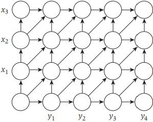

## Sequence alignment: trace-back

**Ex**. Matching *mean* and *name*, with:

- $\delta = 2$,
- mismatch vowels or consonants cost $1$.
- matching vowel and consonant cost $3$.

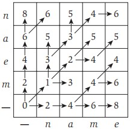

| m | e | a | n | - |
| --- | --- | --- | --- | --- |
| n | - | a | m | e |
| * | - |  | * | - |
| 1 | 2 | 0 | 1 | 2 |

## Sequence alignment: analysis

**Theorem**. The DP algorithm computes the edit distance (and an optimal alignment) of two strings of lengths $m$ and $n$ in $\Theta(mn)$ time and space.  
**Pf**.

**Correctness**.

- Algorithm computes edit distance.
- Can trace back to extract optimal alignment itself.

**Time**. $M$ has $mn$ entries.

# Hirschberg′s algorithm

## Sequence alignment in linear space

**Theorem**. [Hirschberg] There exists an algorithm to find an optimal alignment in $O(mn)$ time and $O(m + n)$ space.

- Clever combination of divide-and-conquer and dynamic programming.

## Hirschberg′s algorithm 1

**Edit distance graph**.

- Let $f(i, j)$ denote length of shortest path from $(0,0)$ to $(i, j)$.
- **Lemma**: $f(i, j) = OPT(i, j)$ for all $i$ and $j$.

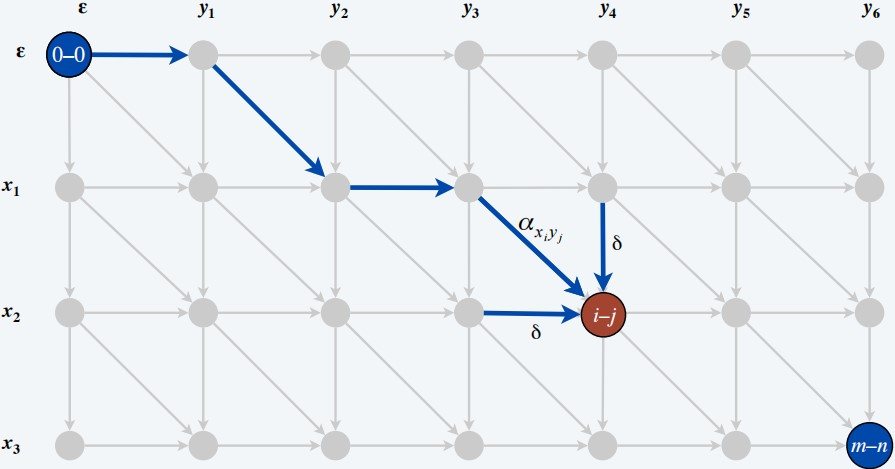

## Hirschberg′s algorithm 1.1

**Edit distance graph**.

- Let $f(i, j)$ denote length of shortest path from $(0,0)$ to $(i, j)$.
- **Lemma**: $f(i, j) = OPT(i, j)$ for all $i$ and $j$.

**Pf of Lemma**. [ by strong induction on $i + j$ ]

- Base case: $f(0, 0) = OPT(0, 0) = 0$.
- Inductive hypothesis: assume true for all $(i', j')$ with $i' + j' < i + j$.
- Last edge on shortest path to $(i, j)$ is from $(i – 1, j – 1)$, $(i – 1, j)$, or $(i, j – 1)$.
- Thus,

$$\begin{aligned}
f(i, j) & = \min \{ \alpha_{x_i,y_j} + f(i-1,j-1), \delta +
f(i-1,j), \delta + f(i,j-1) \} \\
& = \min \{ \alpha_{x_i,y_j} + OPT(i-1,j-1), \delta + OPT(i-1,j),
\delta + OPT(i,j-1) \} \\
& = OPT(i, j) \\
\end{aligned}$$

## Hirschberg′s algorithm 1.2

**Edit distance graph**.

- Let $f(i, j)$ denote length of shortest path from $(0,0)$ to $(i, j)$.
- **Lemma**: $f(i, j) = OPT(i, j)$ for all $i$ and $j$.
- Can compute $f(\cdot, j)$ for any $j$ in $O(mn)$ time and $O(m + n)$ space.

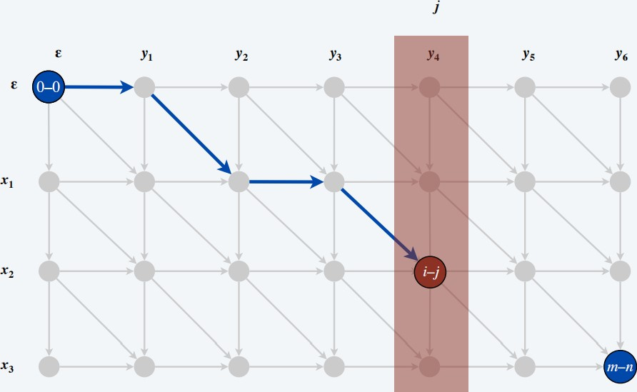

## Hirschberg′s algorithm 2

**Edit distance graph**.

- Let $g(i, j)$ denote length of shortest path from $(i, j)$ to $(m,n)$.

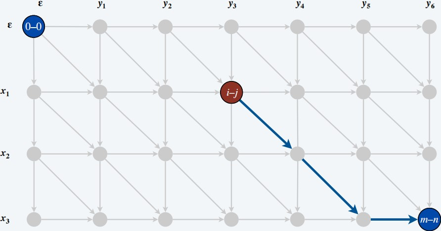

## Hirschberg′s algorithm 2.1

**Edit distance graph**.

- Let $g(i, j)$ denote length of shortest path from $(i, j)$ to $(m,n)$.
- Can compute $g(i, j)$ by reversing the edge orientations and inverting the roles of $(0, 0)$ and $(m, n)$.

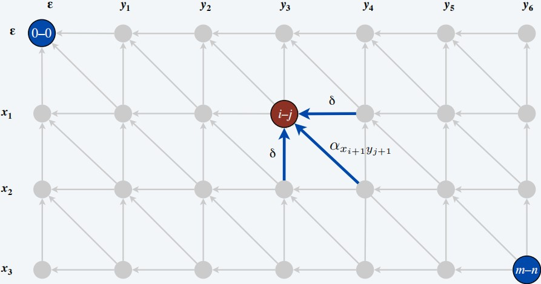

## Hirschberg′s algorithm 2.2

**Edit distance graph**.

- Let $g(i, j)$ denote length of shortest path from $(i, j)$ to $(m,n)$.
- Can compute $g(\cdot, j)$ for any $j$ in $O(mn)$ time and $O(m + n)$ space.

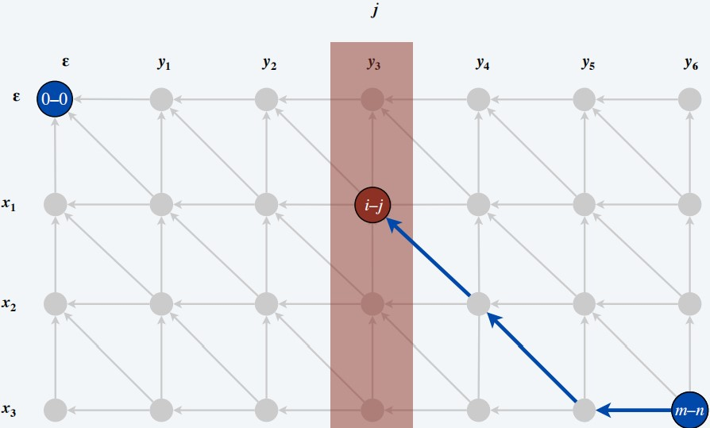

## Hirschberg′s algorithm 3

**Observation 1**. The length of a shortest path that uses $(i, j)$ is $f(i, j) + g(i, j)$.

**Observation 2**. let $q$ be an index that minimizes $f(q, n / 2) + g(q, n / 2)$. Then, there exists a shortest path from $(0, 0)$ to $(m, n)$ that uses $(q, n / 2)$.

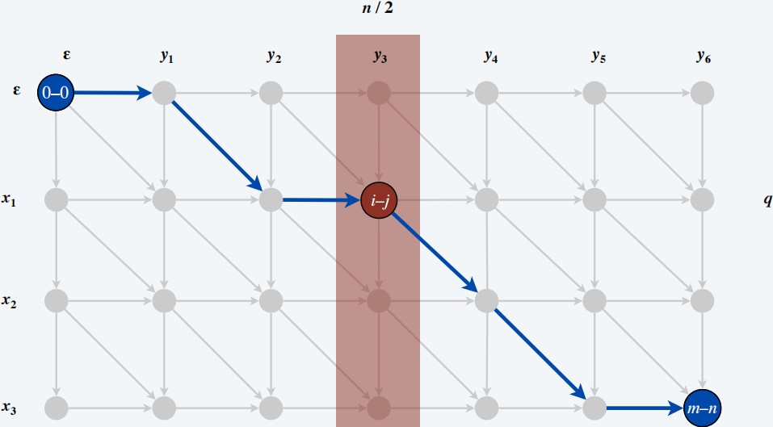

## Hirschberg′s algorithm 4

**Divide**. Find index $q$ that minimizes $f(q, n / 2) + g(q, n / 2)$; save node $i–j$ as part of solution.

**Conquer**. Recursively compute optimal alignment in each piece.

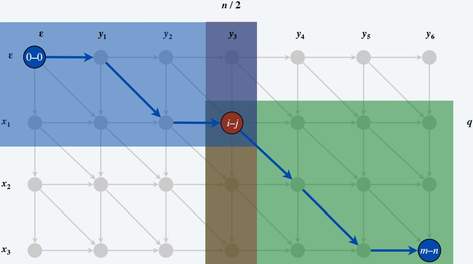

## Hirschberg’s: space analysis

**Theorem**. Hirschberg’s algorithm uses $\Theta(m +n)$ space.  
**Pf**.

- Each recursive call uses $\Theta(m)$ space to compute $f(\cdot, n / 2)$ and $g(\cdot, n / 2)$.
- Only $\Theta(1)$ space needs to be maintained per recursive call.
- Number of recursive calls $\le n$.

## Hirschberg’s: time analysis warmup

**Theorem**. Let $T(m, n)$ = max running time of Hirschberg’s algorithm on strings of lengths at most $m$ and $n$. Then, $T(m, n) = O(m n \log n)$.  
**Pf**.

- $T(m, n)$ is monotone non-decreasing in both $m$ and $n$.
- $T(m, n) \le 2 T(m, n / 2) + O(m n)$
  - $\Rightarrow T(m, n) = O(m n \log n)$.

**Remark**. Analysis is not tight because two sub-problems are of size $(q, n / 2)$ and $(m – q, n / 2)$. Next, we prove $T(m, n) = O(m n)$.

## Hirschberg’s: time analysis

**Theorem**. Let $T(m, n)$ = max running time of Hirschberg’s algorithm on strings of lengths at most $m$ and $n$. Then, $T(m, n) = O(m n)$.  
**Pf**. [ by strong induction on $m + n$ ]

- $O(m n)$ time to compute $f(\cdot, n / 2)$ and $g(\cdot, n / 2)$ and find index $q$.
- $T(q, n / 2) + T(m – q, n / 2)$ time for two recursive calls.
- For some constant $c$:

$$\begin{aligned}
T(m, n) & \le cmn + T(q, n/2) + T(m − q, n/2) \\
T(m, 2) & \le cm \\
T(2, n) & \le cn \\
\end{aligned}$$

**Claim**. $T(m, n) \le 2 c m n$.

## Hirschberg’s: time analysis (cont.)

$$\begin{aligned}
T(m, n) & \le cmn + T(q, n/2) + T(m − q, n/2) \\
T(m, 2) & \le cm \\
T(2, n) & \le cn \\
\end{aligned}$$

**Claim**. $T(m, n) \le 2 c m n$.  
**Pf**. [ by strong induction on $m + n$ ]

- Base cases: $m = 2$ and $n = 2$.

$$\begin{aligned}
T(m, n) & \le T(q, n / 2) + T(m – q, n / 2) + c m n \\
& \le 2 c q n / 2 + 2 c (m – q) n / 2 + c m n \\
& = c q n + c m n – c q n + c m n \\
& = 2 c m n \\
\end{aligned}$$

## Longest Common Subsequence

**Problem**. Given two strings $x_1 x_2 ... x_m$ and $y_1 y_2 ... y_n$, find a common subsequence that is as long as possible.

**Alternative viewpoint**. Delete some characters from $x$; delete some character from $y$; a common subsequence if it results in the same string.

**Ex**. LCS(GGCACCACG, ACGGCGGATACG ) = GGCAACG.

**Applications**. Unix diff, git, bioinformatics.

## Longest Common Subsequence: DP

**Def**. $OPT(i, j)$ = length of LCS of prefix strings $x_1 x_2 ... x_i$ and $y_1 y_2 ... y_j$.

**Goal**. $OPT(m, n)$.

**Case 1**. $x_i = y_j$.

- 1 + length of LCS of $x_1 x_2 ... x_{i-1}$ and $y_1 y_2 ... y_{j–1}$.

**Case 2**. $x_i \ne y_j$.

- Delete $x_i$: length of LCS of $x_1 x_2 ... x_{i-1}$ and $y_1 y_2 ... y_j$.
- Delete $y_j$: length of LCS of $x_1 x_2 ... x_i$ and $y_1 y_2 ... y_{j–1}$.

**Bellman equation**.

$$OPT(i, j) = \left\{ \begin{array}{ll}
0 & \text{if}\ i = 0\ \text{or}\ j = 0\\
1 + OPT(i-1, j-1) & \text{if}\ x_i = y_j \\
\max \{ OPT(i-1,j), OPT(i,j-1) \} & \text{if}\ x_i \ne y_j \\
\end{array}\right.$$

## Longest Common Subsequence: DP II

**Solution 2**. Reduce to finding a min-cost alignment of $x$ and $y$ with

- Gap penalty $δ = 1$
- Mismatch penalty $\alpha$
  - $= 0, \text{if}\ p = q$
  - $= \infty, \text{if}\ p \ne q$
- Edit distance = # gaps = number of characters deleted from $x$ and $y$.
- Length of LCS = ($m + n$ − edit distance) / 2.

**Analysis**. $O(mn)$ time and $O(m + n)$ space.

# Bellman–Ford–Moore algorithm

## Shortest paths with negative weights

**Shortest-path problem**. Given a digraph $G = (V, E)$, with arbitrary edge lengths $l_{vw}$, find shortest path from source node $s$ to destination node $t$.

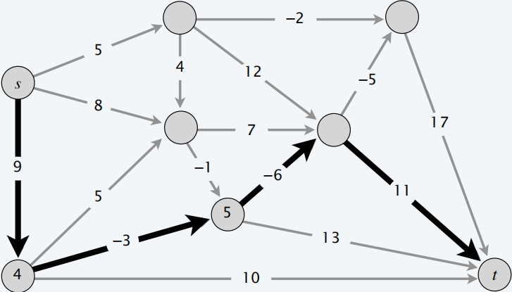

## Greedy attempt

**Dijkstra**. May not produce shortest paths when edge lengths are negative.

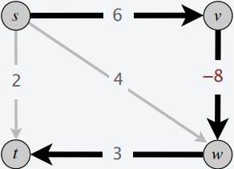

**Re-weighting**. Adding a constant to every edge length does not necessarily make Dijkstra’s algorithm produce shortest paths.

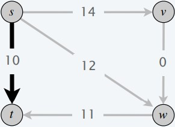

## Negative cycles

**Def**. A negative cycle is a directed cycle for which the sum of its edge lengths is negative.

**Lemma 1**. If some $v \leadsto t$ path contains a negative cycle, then there does not exist a shortest $v \leadsto t$ path.  
**Pf**. If there exists such a cycle $W$, then can build a $v \leadsto t$ path of arbitrarily negative length by detouring around $W$ as many times as desired.

## Negative cycles (cont.)

**Def**. A negative cycle is a directed cycle for which the sum of its edge lengths is negative.

- Among all shortest $v \leadsto t$ paths, consider path $P$ that uses the fewest edges.
- If that path $P$ contains a directed cycle $W$, can remove the portion of $P$ corresponding to $W$ without increasing its length.

## Two problems

**Single-destination shortest-paths problem**. Given a digraph $G = (V, E)$ with edge lengths $l_{vw}$ (but no negative cycles) and a distinguished node $t$, find a shortest $v \leadsto t$ path for every node $v$.

**Negative-cycle problem**. Given a digraph $G = (V, E)$ with edge lengths $l_{vw}$, find a negative cycle (if one exists).

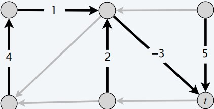

## Quiz: shortest-paths via DP

Which sub-problems to find shortest $v \leadsto t$ paths for every node $v$?

**A**. $OPT(i, v)$ = length of shortest $v \leadsto t$ path that uses *exactly* $i$ edges.  
**B**. $OPT(i, v)$ = length of shortest $v \leadsto t$ path that uses *at most* $i$ edges.  
**C**. Neither A nor B.

A: cannot eliminate shorter paths, since adding a negative edge may greatly reduce length and cancel previous effort, thus reduce to brute-force

## DP for shortest-paths

**Def**. $OPT(i, v)$ = length of shortest $v \leadsto t$ path that uses $\le i$ edges.

**Goal**. $OPT(n – 1, v)$ for each $v$.

**Case 1**. Shortest $v \leadsto t$ path uses $\le i – 1$ edges.

- $OPT(i, v)$ = $OPT(i – 1, v)$.

**Case 2**. Shortest $v \leadsto t$ path uses exactly $i$ edges.

- if $(v, w)$ is first edge in shortest such $v \leadsto t$ path, incur a cost of $l_{vw}$.
- Then, select best w t path using $\le i – 1$ edges.

## DP for shortest-paths: Bellman

**Def**. $OPT(i, v)$ = length of shortest $v \leadsto t$ path that uses $\le i$ edges.

**Goal**. $OPT(n – 1, v)$ for each $v$.

**Case 1**. Shortest $v \leadsto t$ path uses $\le i – 1$ edges.

**Case 2**. Shortest $v \leadsto t$ path uses exactly $i$ edges.

**Bellman equation**.

$$OPT(i, v) = \left\{ \begin{array}{ll}
0 & \text{if}\ i = 0\ \text{and}\ v = t\\
\infty & \text{if}\ i = 0\ \text{and}\ v \ne t\\
\min \{OPT(i-1, v),\min_{(v,w) \in E} \{OPT(i-1,w) + l_{vw}\} \} &
\text{if}\ i > 0 \\
\end{array}\right.$$

## DP for shortest-paths: algorithm

`SHORTEST-PATHS`($V, E, l, t$)

1. FOREACH node $v \in V$: $M[0, v] = \infty$;
2. $M[0, t] = 0$;
3. FOR $i = 1 .. n – 1$:
   1. FOREACH node $v \in V$:
      1. $M[i, v] = M[i – 1, v]$;
      2. FOREACH edge $(v, w) \in E$: $M[i, v] = min \{ M[i, v], M[i – 1, w] + l_{vw} \}$;

$$OPT(i, v) = \left\{ \begin{array}{ll}
0 & \text{if}\ i = 0\ \text{and}\ v = t\\
\infty & \text{if}\ i = 0\ \text{and}\ v \ne t\\
\min \{OPT(i-1, v),\min_{(v,w) \in E} \{OPT(i-1,w) + l_{vw}\} \} &
\text{if}\ i > 0 \\
\end{array}\right.$$

## DP for shortest-paths: analysis

**Theorem 1**. Given a digraph $G = (V, E)$ with no negative cycles, the DP algorithm computes the length of a shortest $v \leadsto t$ path for every node $v$ in $\Theta(mn)$ time and $\Theta(n^2)$ space.  
**Pf**.

- Table requires $\Theta(n^2)$ space.
- Each iteration $i$ takes $\Theta(m)$ time since we examine each edge once.

## DP for shortest-paths: trace-back

**Finding the shortest paths**.

- Approach 1: Maintain `successor`[$i, v$] that points to next node on a shortest $v \leadsto t$ path using $\le i$ edges.
- Approach 2: Compute optimal lengths $M[i, v]$ and consider only edges with $M[i, v] = M[i – 1, w] + l_{vw}$. Any directed path in this subgraph is a shortest path.

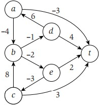

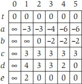

## Quiz: DP for shortest-paths

It is easy to modify the DP algorithm for shortest paths to …

**A**. Compute lengths of shortest paths in $O(mn)$ time and $O(m + n)$ space.  
**B**. Compute shortest paths in $O(mn)$ time and $O(m + n)$ space.  
**C**. Both A and B.  
**D**. Neither A nor B.

## Shortest-paths: practical improvements

**Space optimization**. Maintain two 1D arrays (instead of 2D array).

- $d[v]$ = length of a shortest $v \leadsto t$ path that we have found so far.
- `successor`[v] = next node on a $v \leadsto t$ path.

**Performance optimization**. If $d[w]$ was not updated in iteration $i – 1$, then no reason to consider edges entering $w$ in iteration $i$.

## Bellman–Ford–Moore

`BELLMAN–FORD–MOORE`($V, E, c, t$)

1. FOREACH node $v \in V$:
   1. $d[v] = \infty$;
   2. `successor`[$v$] = `null`;
2. $d[t] = 0$;
3. FOR $i = 1 .. n – 1$:
   1. FOREACH node $w \in V$:
      1. IF ($d[w]$ was updated in previous pass):
         1. FOREACH edge $(v, w) \in E$:
            1. IF ($d[v] > d[w] + l_{vw}$) $d[v] = d[w] + l_{vw}$;
            2. `successor`[$v$] = $w$;
   2. IF (no $d[\cdot]$ value changed in pass $i$): `STOP`;

## Quiz: Bellman–Ford–Moore

Which properties must hold after pass $i$ of Bellman–Ford–Moore?

**A**. $d[v]$ = length of a shortest $v \leadsto t$ path using $\le i$ edges.  
**B**. $d[v]$ = length of a shortest $v \leadsto t$ path using exactly $i$ edges.  
**C**. Both A and B.  
**D**. Neither A nor B.

D. Now $i$ is just a counter of $n-1$ iterations.

## Bellman–Ford–Moore: analysis

**Lemma 3**. For each node $v$: $d[v]$ is the length of some $v \leadsto t$ path.  
**Lemma 4**. For each node $v$: $d[v]$ is monotone non-increasing.

**Lemma 5**. After pass $i$, $d[v] \le$ length of a shortest $v \leadsto t$ path using $\le i$ edges.  
**Pf**. [ by induction on $i$ ]

- Base case: $i = 0$; Assume true after pass $i$.
- Let $P$ be any $v \leadsto t$ path with $\le i + 1$ edges.
- Let $(v, w)$ be first edge in $P$ and let $P'$ be subpath from $w$ to $t$.
- By inductive hypothesis, at the end of pass $i$, $d[w] \le l(P')$, because $P'$ is a $w \leadsto t$ path with $\le i$ edges.
- After considering edge $(v, w)$ in pass $i + 1$:

$$\begin{aligned}
d[v] & \le l_{vw} + d[w] \\
& \le l_{vw} + l(P') \\
& = l(P) \\
\end{aligned}$$

## Bellman–Ford–Moore: analysis (cont.)

- shortest path exists and has at most $n−1$ edges
- after $i$ passes, $d[v] \le$ length of shortest path that uses $\le i$ edges

**Remark**. Bellman–Ford–Moore is typically faster in practice.

- Edge $(v, w)$ considered in pass $i + 1$ only if $d[w]$ updated in pass $i$.
- If shortest path has $k$ edges, then algorithm finds it after $\le k$ passes.

## Quiz: Bellman–Ford–Moore trace-back

Assuming no negative cycles, which properties must hold throughout Bellman–Ford–Moore?

**A**. Following `successor`[$v$] pointers gives a directed $v \leadsto t$ path.  
**B**. If following `successor`[$v$] pointers gives a directed $v \leadsto t$ path, *then* the length of that $v \leadsto t$ path is $d[v]$.  
**C**. Both A and B.  
**D**. Neither A nor B.

## Bellman–Ford–Moore: trace-back

**Claim**. Throughout Bellman–Ford–Moore, following the `successor`[$v$] pointers gives a directed path from v to t of length $d[v]$.

**Counterexample**. Claim is false!

- Length of successor $v \leadsto t$ path may be strictly shorter than $d[v]$.

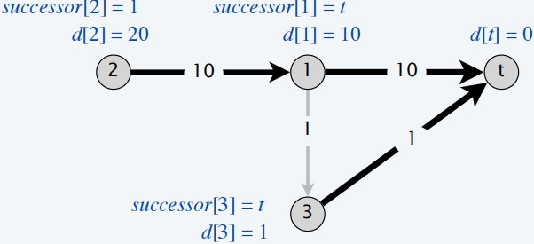

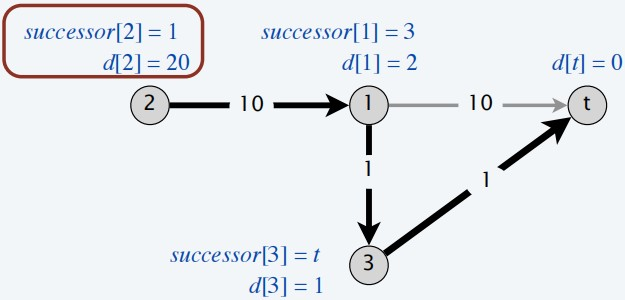

## Bellman–Ford–Moore: trace-back

**Claim**. Throughout Bellman–Ford–Moore, following the `successor`[$v$] pointers gives a directed path from v to t of length $d[v]$.

**Counterexample**. Claim is false!

- Length of successor $v \leadsto t$ path may be strictly shorter than $d[v]$.
- With negative cycle, successor graph may have directed cycles.

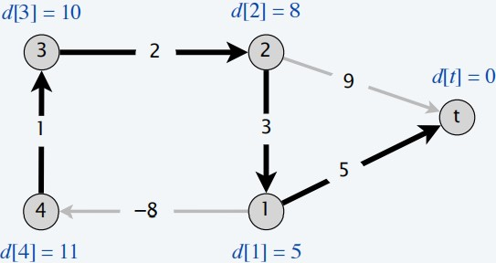

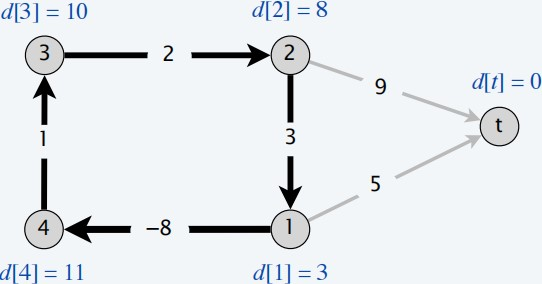

## Bellman–Ford–Moore: shortest paths

**Lemma 6**. Any directed cycle $W$ in the successor graph is a negative cycle.  
**Pf**.

- If `successor`[$v$] = $w$, we must have $d[v] \ge d[w] + l_{vw}$.
- Let $v_1 \rightarrow v_2 \rightarrow \ldots \rightarrow v_k \rightarrow v_1$ be sequence in a directed cycle $W$.
- Assume that $(v_k, v_1)$ is the last edge in $W$ added to successor graph.
- Just prior to that:

$$\begin{aligned}
d[v_1] & \ge l(v_1, v_2) + d[v_2] \\
% d[v_2] & \ge l(v_2, v_3) + d[v_3] \\
& \vdots \\
d[v_{k–1}] & \ge l(v_{k–1}, v_k) + d[v_k] \\
d[v_k] & > l(v_k, v_1) + d[v_1] \ \text{strict less: updating
now} \\
\end{aligned}$$

- Adding inequalities yields $l(v_1, v_2) + l(v_2, v_3) + \ldots + l(v_{k–1}, v_k) + l(v_k, v_1) < 0$.

## BFM: shortest paths (cont.)

**Theorem 3**. Assuming no negative cycles, Bellman–Ford–Moore finds shortest $v \leadsto t$ paths for every node $v$ in $O(mn)$ time and $\Theta(n)$ extra space.  
**Pf**.

- The successor graph cannot have a directed cycle. [Lemma 6]
- Let $P$: $v = v_1 \rightarrow v_2 \rightarrow \ldots \rightarrow v_k = t$ be following successor pointers.
- Upon termination, if `successor`[$v$] = $w$, we must have $d[v] = d[w] + l_{vw}$.

$$\begin{aligned}
d[v_1] & = l(v_1, v_2) + d[v_2] \\
d[v_2] & = l(v_2, v_3) + d[v_3] \\
& \vdots \\
d[v_{k–1}] & = l(v_{k–1}, v_k) + d[v_k] \\
\end{aligned}$$

- Adding equations yields $d[v] = d[t] + l(v_1, v_2) + l(v_2, v_3) + \ldots + l(v_{k–1}, v_k)$.

# Distance-vector protocols

## Communication network

**Communication network**.

- Node ≈ router.
- Edge ≈ direct communication link.
- Length of edge ≈ latency of link.

**Dijkstra’s algorithm**. Requires global information of network.

**Bellman–Ford–Moore**. Uses only local knowledge of neighboring nodes.

**Synchronization**. We don’t expect routers to run in lockstep.

- The order in which each edges are processed in Bellman–Ford–Moore is not important.
- Moreover, algorithm converges even if updates are asynchronous.

## Distance-vector routing protocols

**Distance-vector routing protocols**. [ “routing by rumor” ]

- Each router maintains a vector of shortest-path lengths to every other node (**distances**) and the *first hop* on each path (**directions**).
- **Algorithm**: each router performs $n$ separate computations, one for each potential destination node.

**Ex**. Routing Information Protocol (RIP), Xerox XNS RIP, Novell’s IPX RIP, Cisco’s IGRP, DEC’s DNA Phase IV, AppleTalk’s RTMP.

**Caveat**. Edge lengths may *change* during algorithm (or fail completely).

## Path-vector routing protocols

**Link-state routing protocols**.

- Each router stores the *whole path* (or network topology).
- Based on Dijkstra’s algorithm.
- Avoids “counting-to-infinity” problem and related difficulties.
- Requires significantly more storage.

**Ex**. Border Gateway Protocol (BGP), Open Shortest Path First (OSPF).

# Negative cycles

## Detecting negative cycles

**Negative cycle detection problem**. Given a digraph $G = (V, E)$, with edge lengths $l_{vw}$, find a negative cycle (if one exists).

## Detecting negative cycles: application

**Currency conversion**. Given $n$ currencies and exchange rates between pairs of currencies, is there an arbitrage opportunity?

**Remark**. Fastest algorithm very valuable!

## Detecting negative cycles - I

**Lemma 7**. If $OPT(n, v) = OPT(n – 1, v)$ for every node $v$, then no negative cycles.  
**Pf**. The $OPT(n, v)$ values have converged $\Rightarrow$ shortest $v \leadsto t$ path exists.

**Lemma 8**. If $OPT(n, v) < OPT(n – 1, v)$ for some node $v$, then (any) shortest $v \leadsto t$ path of length $\le n$ contains a cycle $W$. Moreover $W$ is a negative cycle.  
**Pf**. [by contradiction]

- Since $OPT(n, v) < OPT(n – 1, v)$, we know that shortest $v \leadsto t$ path $P$ has exactly $n$ edges.
- By *pigeonhole principle*, the path $P$ must contain a repeated node $x$.
- Let $W$ be any cycle in $P$.
- Deleting $W$ yields a $v \leadsto t$ path with $< n$ edges $\Rightarrow W$ is a negative cycle.

## Detecting negative cycles - II

**Theorem 4**. Can find a negative cycle in $Θ(mn)$ time and $Θ(n2)$ space.  
**Pf**.

Construct **Augmented graph $Gʹ$**: Add new sink node $t$ and connect all nodes to $t$ with $0$-length edge.

- $G$ has a negative cycle iff $Gʹ$ has a negative cycle.

Case 1. [ $OPT(n, v) = OPT(n – 1, v)$ for every node $v$ ]

- By Lemma 7, no negative cycles.

Case 2. [ $OPT(n, v) < OPT(n – 1, v)$ for some node $v$ ]

- Using proof of Lemma 8, can extract negative cycle from $v↝t$ path. (cycle cannot contain $t$ since no edge leaves $t$)

## Detecting negative cycles - III

**Theorem 5**. Can find a negative cycle in $O(mn)$ time and $O(n)$ extra space.  
**Pf**.

- Run `Bellman–Ford–Moore` on $Gʹ$ for $nʹ = n + 1$ passes (instead of $nʹ – 1$).
- If no $d[v]$ values updated in pass $nʹ$, then no negative cycles.
- Otherwise, suppose $d[s]$ updated in pass $nʹ$.
- Define `pass`($v$) = last pass in which $d[v]$ was updated.
- Observe `pass`($s$) = $nʹ$ and `pass`(`successor`[$v$]) $\ge$ `pass`($v$) $– 1$ for each $v$.
- Following successor pointers, we must eventually repeat a node.
- Lemma 6 $\Rightarrow$ the corresponding cycle is a negative cycle.